# Week 1 Homework

Author

Anna Hiltner Nouzeilles

# Probability

## Marginal Probability

The *marginal probability* of a runner being Kenyan is 0.023%

$$P(\text{Kenya}) = \frac{4+9}{3 + 4 + 3 + 38000+ 9 + 18000} = .00023$$

The *marginal probability* of a runner being American is 67.9%

$$P(\text{USA}) = \frac{3 + 38000}{3 + 4 + 3 + 38000+ 9 + 18000} = 0.6786$$

## Joint probability

The *joint probability* of being Kenyan and ending up in the top 10 $P(\text{Kenya} \cap \text{Top10})$ is about 0.0071%

$$P(\text{Kenya} \cap \text{Top10}) = \frac{4}{3 + 4 + 3 + 38000+ 9 + 18000} = 0.0000714$$

The *joint probability* of being Kenyan and ending up outside the top 10 $P(\text{Kenya} \cap \text{NotTop 10})$ is about 0.0161%

$$P(\text{Kenya} \cap \text{NotTop10}) = \frac{9}{3 + 4 + 3 + 38000+ 9 + 18000} = 0.000161$$

## Conditional Probability

The *conditional probability* of being in the top 10 given that a runner is Kenyan is about 30.8%

$$P(\text{Top10} | \text{Kenyan}) = \frac{\tfrac{4}{56019}}{\tfrac{13}{56019}} = 0.3077$$

The *conditional probability* of being Kenyan given that a runner is in the top 10 is about 40%

$$P(\text{Kenyan} | \text{Top10}) = \frac{\tfrac{4}{56019}}{\tfrac{10}{56019}} = .4$$

If we wanted to compare the performance of US and Kenyan runner using conditional probabilities, we would look at the conditional probability of being in the top 10 give that the runner is Kenyan or American because it accounts for the number of runners each country sends and measures how likely it is that a runner from each country makes it into the top 10.

# Regression Review

## (a) NYC Marathon Finishing Times

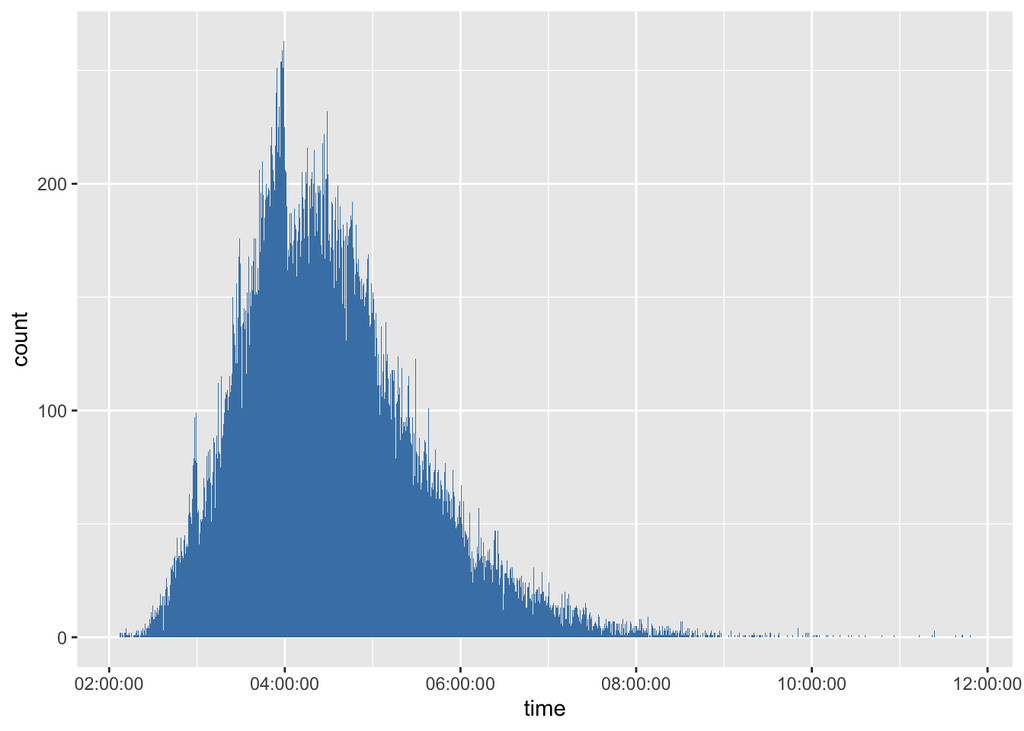

The distribution of finishing times is slightly right skewed (because of outliers with longer times) with a peak at 4 hours. The sharp rises suggest that runners tend to cluster around common finishing time goals such as 3, 3.5, 4, 4.5 hours. They train to finish the race at specific times and the race reflects that because people adjust their pace to finish by their goal.

## Random Sample

**(b)**

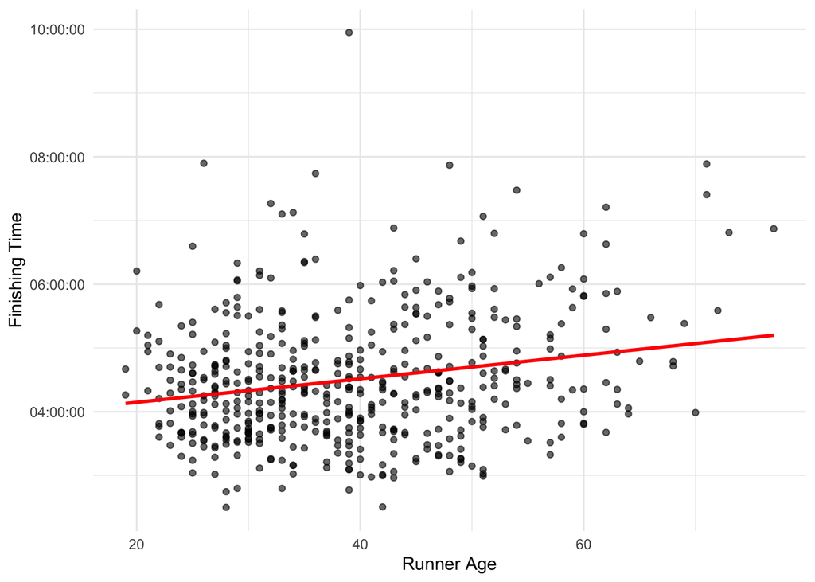

```
Call:
lm(formula = timemin ~ age, data = sample)

Residuals:
    Min      1Q  Median      3Q     Max
-122.84  -39.83   -7.88   31.93  327.02

Coefficients:
            Estimate Std. Error t value Pr(>|t|)
(Intercept) 226.7236     9.4024  24.113  < 2e-16 ***
age           1.1075     0.2301   4.813 1.97e-06 ***
---
Signif. codes:  0 '***' 0.001 '**' 0.01 '*' 0.05 '.' 0.1 ' ' 1

Residual standard error: 59.17 on 498 degrees of freedom
Multiple R-squared:  0.04445,   Adjusted R-squared:  0.04253
F-statistic: 23.17 on 1 and 498 DF,  p-value: 1.973e-06
```

**(c)** The intercept of 226.7 tells us the predicted finishing time in minutes when age = 0. Even though this is not useful since nobody at age zero runs a marathon, it tells us where the regression line crosses the y-axis and can be used to predict the finishing times for other ages. The age coefficient of 1.1 tells us that for each additional year of age, finishing time increases by about 1.1 minutes in this sample.

$$\hat{time} = \beta_{0} + \beta_{1} \cdot age$$

## (e) Two Regressions

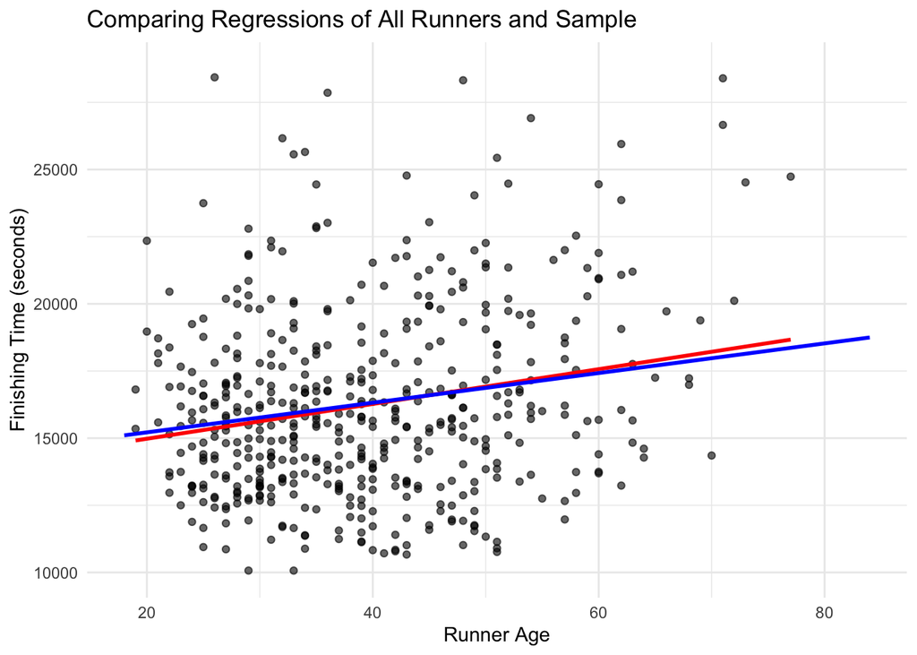

The two regression lines differ slightly. The red line shows the regression for the random sample of 500 while the blue line shows the regression for all of the data. In the random sample, the line is steeper which means the effect of age on finishing time is slightly overestimated compared to the full dataset. Taking a larger sample from the population would make the lines more similar.

## (f) Repeated Samples

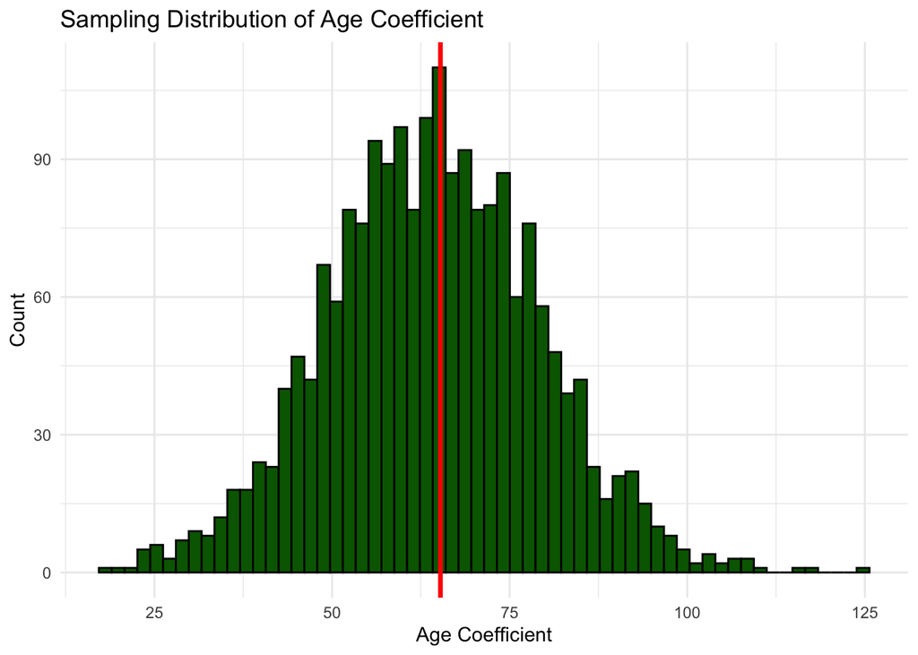

As an example of the Central Limit Theorem, the estimated coefficients from the 2000 samples of n=500 create a normal distribution with the age coefficient of the whole sample at its center.